# Peat Depth Model Selection

Christoph Kratz

Author: “Christoph Kratz”  
Project: “National Peat Depth Model”  
Time run: 2017-08-26 20:00:07

## Outline

This script uses the peat depth and environmental data used in the original CEH peat depth model. It tries out a number of models and evaluates them.

## Packages

```r
library(raster)
library(rgdal)
library(randomForest)
```

```r
library(caTools)
library(ggplot2)
```

## Data preparation

### Import data

```r
#import raw data - note that filepath must be explicitly stated for Rmd
input.data <- readRDS("E://National_Peat_Depth_map/data/input.data.rds")
```

### Split into training and test set

```r
set.seed(123)
split = sample.split(input.data$PEAT_DEPTH, SplitRatio = 2/3)
training_set = subset(input.data, split == TRUE)
test_set = subset(input.data, split == FALSE)
```

### Feature Scaling

```r
#not sure needed

# training_set = scale(training_set)
# test_set = scale(test_set)
```

## Linear model

### Linear model 1

Run linear models

```r
M.lm <- lm(PEAT_DEPTH ~ ., data=training_set)
```

summarise model outputs:

```r
summary(M.lm)
```

```
##
## Call:
## lm(formula = PEAT_DEPTH ~ ., data = training_set)
##
## Residuals:
##      Min       1Q   Median       3Q      Max
## -307.581   -5.968   -0.735    5.041  138.134
##
## Coefficients:
##                                   Estimate Std. Error t value Pr(>|t|)
## (Intercept)                      2.966e+02  1.727e+01  17.172  < 2e-16 ***
## LCM2007                          6.657e-01  3.363e-02  19.793  < 2e-16 ***
## SLOPE                           -1.243e+00  7.805e-02 -15.921  < 2e-16 ***
## ELEVATION                       -3.141e-03  5.235e-03  -0.600   0.5485
## MEAN_AN_RF                       6.626e-03  4.488e-03   1.476   0.1398
## rfi                              7.364e+00  1.522e+00   4.840 1.30e-06 ***
## ETR                             -5.370e+00  3.523e-01 -15.242  < 2e-16 ***
## growseason                       2.577e+00  4.767e-02  54.069  < 2e-16 ***
## consdryday                      -6.349e+01  1.227e+00 -51.728  < 2e-16 ***
## X10mm_raind                      3.509e-01  1.777e-01   1.975   0.0483 *
## PEATTYPELowland fen peats        1.547e+02  9.236e+00  16.753  < 2e-16 ***
## PEATTYPELowland raised bog peat  2.934e+02  9.212e+00  31.851  < 2e-16 ***
## PEATTYPEUpland blanket bog peat  4.035e+01  9.081e+00   4.444 8.86e-06 ***
## coords.x1                        9.777e-05  1.093e-05   8.943  < 2e-16 ***
## coords.x2                       -9.171e-06  8.516e-06  -1.077   0.2816
## coords.x3                        9.666e-01  2.031e-03 475.863  < 2e-16 ***
## ---
## Signif. codes:  0 '***' 0.001 '**' 0.01 '*' 0.05 '.' 0.1 ' ' 1
##
## Residual standard error: 36.13 on 52324 degrees of freedom
## Multiple R-squared:  0.895,  Adjusted R-squared:  0.895
## F-statistic: 2.973e+04 on 15 and 52324 DF,  p-value: < 2.2e-16
```

Plot model summary:

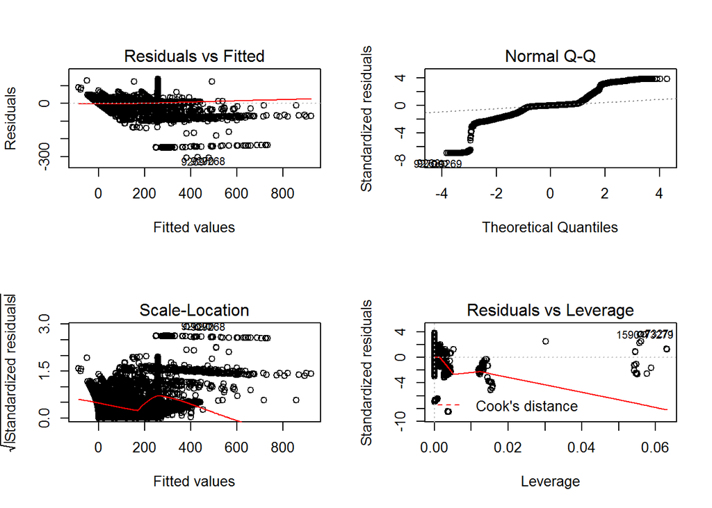

```r
par(mfrow = c(2,2))
plot(M.lm)
```

```r
par(mfrow = c(1,1))
```

#### Predict and evaluate model

Predict test values using model

```r
pred.lm <- predict(M.lm, test_set[-1])
```

calculate mean squared difference between predicted and actual results

```r
mean(pred.lm)
```

```
## [1] 177.6337
```

```r
mean(test_set$PEAT_DEPTH)
```

```
## [1] 177.531
```

```r
test.err.lm <- mean((test_set$PEAT_DEPTH - pred.lm)^2)
test.err.lm
```

```
## [1] 1538.584
```

Histogram of differences between prediction and actuals:

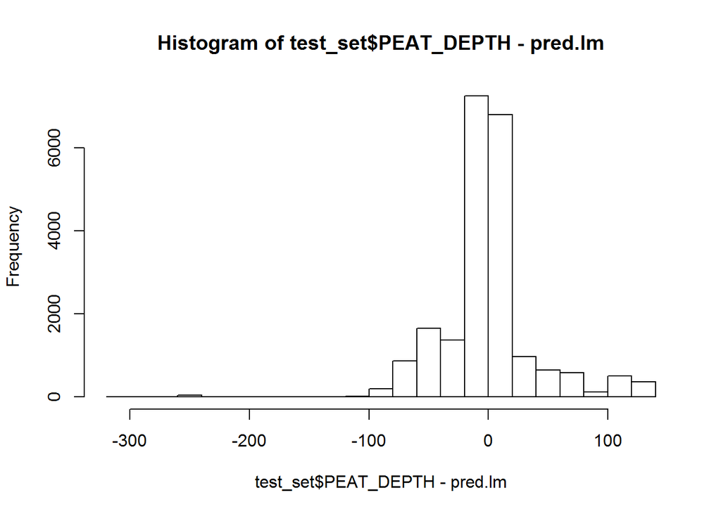

```r
hist(test_set$PEAT_DEPTH - pred.lm)
```

scatterplot of differences between prediction and actuals

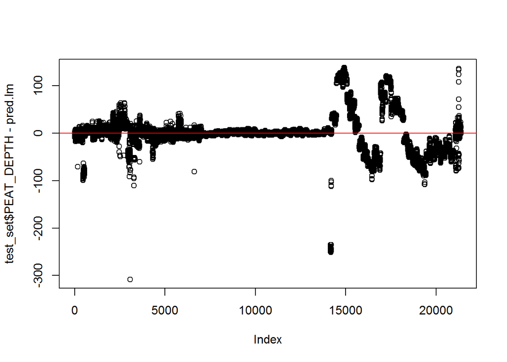

```r
plot(test_set$PEAT_DEPTH - pred.lm)
abline(0,0, col="red")
```

## Random Forest Model

### Random Forest Model 1

Run random forest model *takes quite long to run, like hours man.*

```r
# M.rf <- randomForest(PEAT_DEPTH ~ ., data=training_set)
```

```r
#saveRDS(M.rf, file="data/M.rf.CEH.rds") #save to file
M.rf <- readRDS("E://National_Peat_Depth_map/data/M.rf.CEH.rds")
```

report model outputs:

```r
M.rf
```

```
##
## Call:
##  randomForest(formula = PEAT_DEPTH ~ ., data = training_set)
##                Type of random forest: regression
##                      Number of trees: 500
## No. of variables tried at each split: 4
##
##           Mean of squared residuals: 27.18506
##                     % Var explained: 99.78
```

summarise model output

```r
summary(M.rf)
```

```
##                 Length Class  Mode
## call                3  -none- call
## type                1  -none- character
## predicted       52340  -none- numeric
## mse               500  -none- numeric
## rsq               500  -none- numeric
## oob.times       52340  -none- numeric
## importance         13  -none- numeric
## importanceSD        0  -none- NULL
## localImportance     0  -none- NULL
## proximity           0  -none- NULL
## ntree               1  -none- numeric
## mtry                1  -none- numeric
## forest             11  -none- list
## coefs               0  -none- NULL
## y               52340  -none- numeric
## test                0  -none- NULL
## inbag               0  -none- NULL
## terms               3  terms  call
```

Plot model summary:

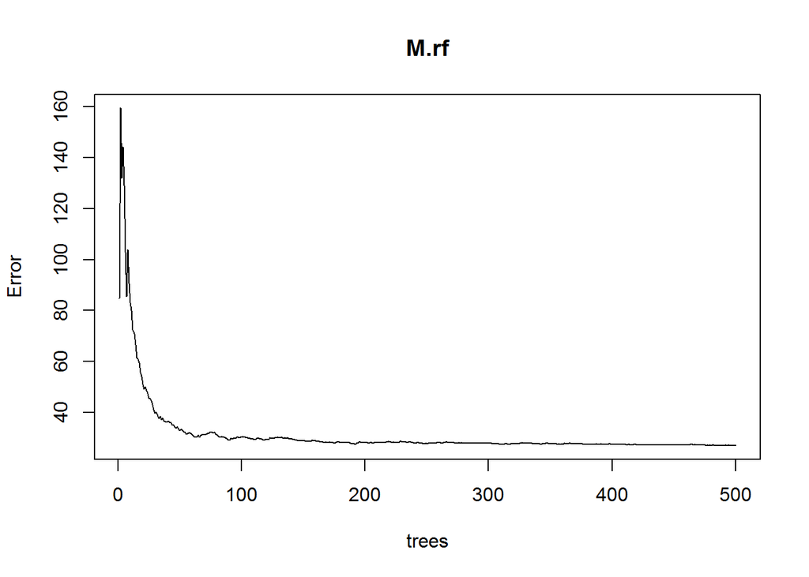

```r
plot(M.rf)
```

#### Predict and evaluate model

Predict test values using model

```r
pred.rf <- predict(M.rf, test_set[-1])
```

calculate mean squared difference between predicted and actual results

```r
mean(pred.rf)
```

```
## [1] 177.5422
```

```r
mean(test_set$PEAT_DEPTH)
```

```
## [1] 177.531
```

```r
test.err.rf <- mean((test_set$PEAT_DEPTH - pred.rf)^2)
test.err.rf
```

```
## [1] 21.99689
```

Histogram of differences between prediction and actuals:

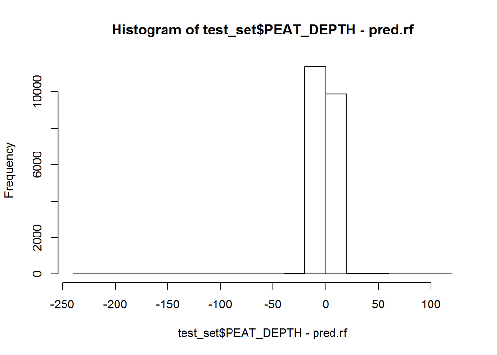

```r
hist(test_set$PEAT_DEPTH - pred.rf)
```

lets zoom in on that histogram:

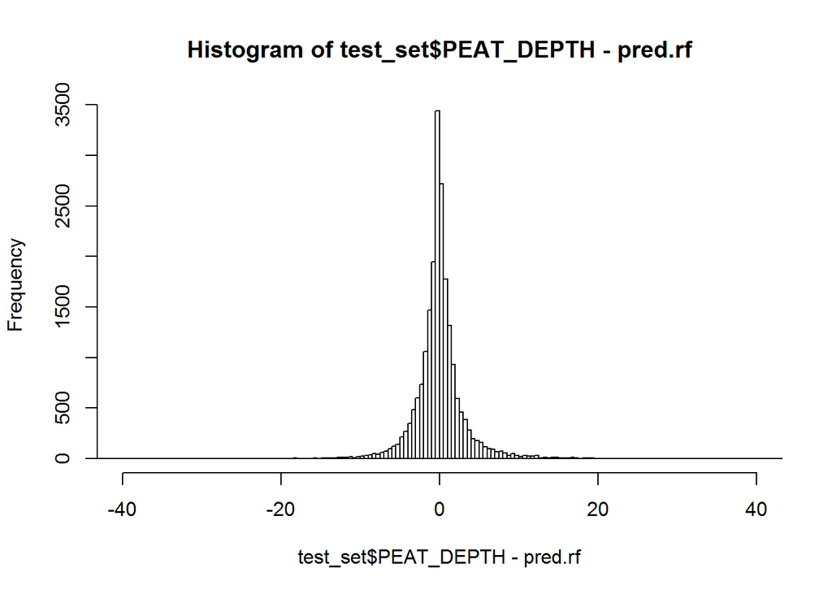

```r
hist(test_set$PEAT_DEPTH - pred.rf, breaks = 500, xlim = c(-40,40))
```

scatterplot of differences between prediction and actuals

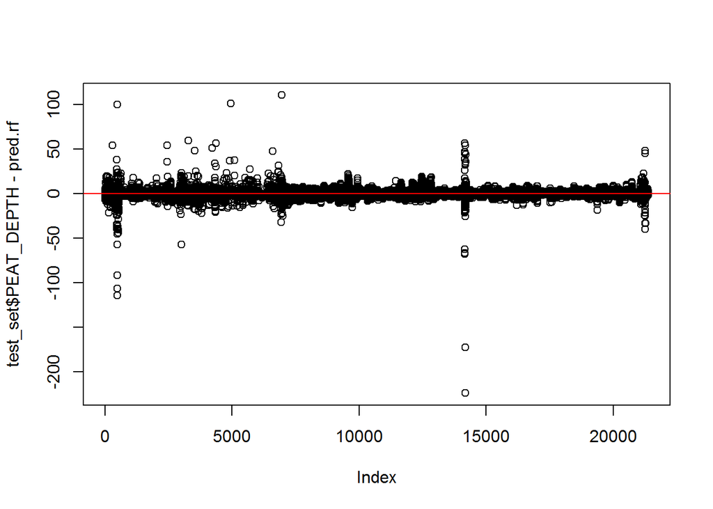

```r
plot(test_set$PEAT_DEPTH - pred.rf)
abline(0,0, col="red")
```

Is there a relationship between the error and peat depth:

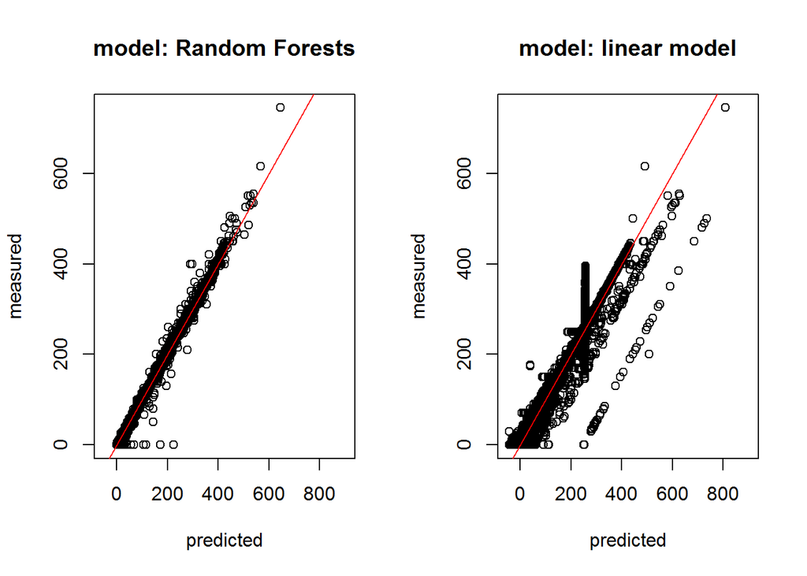

```r
par(mfrow = c(1,2))
plot(test_set$PEAT_DEPTH ~ pred.rf, main = "model: Random Forests", ylab = "measured",  xlab = "predicted",
     xlim = c(-50,900))
abline(0,1, col="red")
plot(test_set$PEAT_DEPTH ~ pred.lm, main = "model: linear model", ylab = "measured",  xlab = "predicted",
     xlim = c(-50,900))
abline(0,1, col="red")
```

```r
par(mfrow = c(1,1))
```

There are negative depths in both models:

```r
range(pred.lm)
```

```
## [1] -108.4362  808.9671
```

```r
range(pred.rf)
```

```
## [1] -8.624852e-13  6.452181e+02
```

But the linear model’s negatives got down to -108.44 metres whereas the random forest model’s most negative figure is in the nanometres: -8.624851910^{-13}